# assignment

Jan Matthias

2023-03-28

```r
suppressPackageStartupMessages({
  library(AnnotationHub)
  library(ensembldb)
  library(GenomicRanges)
  library(epiwraps)
  library(rtracklayer)
  library(ggplot2)
})
download.file("https://www.encodeproject.org/files/ENCFF247GVM/@@download/ENCFF247GVM.bed.gz", dest="H3K4me3.bed.gz")
download.file("https://www.encodeproject.org/files/ENCFF008XKX/@@download/ENCFF008XKX.bed.gz", dest="H3K27me3.bed.gz")
```

1. Importing the embryonic methylation peaks

```r
peaks_H3K27me3 <-  rtracklayer::import("H3K27me3.bed.gz", format="narrowPeak")
peaks_H3K4me3 <- rtracklayer::import("H3K4me3.bed.gz",format="narrowPeak")

peaksOverlapsMarks <- overlapsAny(peaks_H3K4me3, peaks_H3K27me3 )
table(peaksOverlapsMarks)
```

```
## peaksOverlapsMarks
## FALSE  TRUE
## 49280  3219
```

2. Subsetting the initial data set (in this case the H3K4me3 peaks)

```r
subset_H3K4me3 <- subsetByOverlaps(peaks_H3K4me3, peaks_H3K27me3 ) # to verify
subset_H3K4me3
```

```
## GRanges object with 3219 ranges and 6 metadata columns:
##          seqnames              ranges strand |        name     score
##             <Rle>           <IRanges>  <Rle> | <character> <numeric>
##      [1]    chr10 103027946-103028834      * |  Peak_23452        88
##      [2]    chr10   10557574-10558275      * |   Peak_8134       347
##      [3]    chr10 107271523-107272943      * |  Peak_20198       119
##      [4]    chr10 110455143-110455843      * |  Peak_17609       153
##      [5]    chr10 111010890-111011348      * |  Peak_33245        42
##      ...      ...                 ...    ... .         ...       ...
##   [3215]     chrX   93288695-93289423      * |  Peak_38814        31
##   [3216]     chrX   93298999-93299534      * |  Peak_35832        36
##   [3217]     chrX   94234909-94235926      * |  Peak_15668       185
##   [3218]     chrX   99216536-99216846      * |  Peak_35595        36
##   [3219]     chrX   99821367-99821966      * |  Peak_25491        74
##          signalValue    pValue    qValue      peak
##            <numeric> <numeric> <numeric> <integer>
##      [1]    11.13573   41.6954   39.2384       503
##      [2]    26.40615  171.9882  168.6594       557
##      [3]     9.74797   57.1880   54.6209       463
##      [4]    11.52869   74.4171   71.7384       438
##      [5]     8.75254   18.3780   16.1310       188
##      ...         ...       ...       ...       ...
##   [3215]     5.29077   12.6201   10.4467       371
##   [3216]     7.56097   15.2574   13.0477       218
##   [3217]    21.69724   90.6395   87.8586       180
##   [3218]     6.61347   15.4524   13.2398       191
##   [3219]    13.12184   34.5218   32.1202       332
##   -------
##   seqinfo: 27 sequences from an unspecified genome; no seqlengths
```

```r
# another way of doing it is
subset_2 <- peaks_H3K4me3[peaksOverlapsMarks[TRUE]]
subset_2
```

```
## GRanges object with 3219 ranges and 6 metadata columns:
##          seqnames              ranges strand |        name     score
##             <Rle>           <IRanges>  <Rle> | <character> <numeric>
##      [1]    chr10 103027946-103028834      * |  Peak_23452        88
##      [2]    chr10   10557574-10558275      * |   Peak_8134       347
##      [3]    chr10 107271523-107272943      * |  Peak_20198       119
##      [4]    chr10 110455143-110455843      * |  Peak_17609       153
##      [5]    chr10 111010890-111011348      * |  Peak_33245        42
##      ...      ...                 ...    ... .         ...       ...
##   [3215]     chrX   93288695-93289423      * |  Peak_38814        31
##   [3216]     chrX   93298999-93299534      * |  Peak_35832        36
##   [3217]     chrX   94234909-94235926      * |  Peak_15668       185
##   [3218]     chrX   99216536-99216846      * |  Peak_35595        36
##   [3219]     chrX   99821367-99821966      * |  Peak_25491        74
##          signalValue    pValue    qValue      peak
##            <numeric> <numeric> <numeric> <integer>
##      [1]    11.13573   41.6954   39.2384       503
##      [2]    26.40615  171.9882  168.6594       557
##      [3]     9.74797   57.1880   54.6209       463
##      [4]    11.52869   74.4171   71.7384       438
##      [5]     8.75254   18.3780   16.1310       188
##      ...         ...       ...       ...       ...
##   [3215]     5.29077   12.6201   10.4467       371
##   [3216]     7.56097   15.2574   13.0477       218
##   [3217]    21.69724   90.6395   87.8586       180
##   [3218]     6.61347   15.4524   13.2398       191
##   [3219]    13.12184   34.5218   32.1202       332
##   -------
##   seqinfo: 27 sequences from an unspecified genome; no seqlengths
```

```r
# can see that in the output we have the same range value
```

Here I used two different ways of subsetting the peaks_H3K4me3. Both results yield the same amount of objects within the Granges (3219)

3. Downloading the new differentiated cell type (myoblast, differentiated cell)

```r
dir.create("peaks")
download.file("https://www.encodeproject.org/files/ENCFF360QRN/@@download/ENCFF360QRN.bed.gz", dest="peaks/H3K4me3_myo.bed.gz")
download.file("https://www.encodeproject.org/files/ENCFF071FEL/@@download/ENCFF071FEL.bed.gz", dest="peaks/H3K27me3_myo.bed.gz")

# importing manually
mark_H3K27me3_myo <-  rtracklayer::import("H3K27me3_myo.bed.gz", format="narrowPeak")
mark_H3K4me3_myo <- rtracklayer::import("H3K4me3_myo.bed.gz",format="narrowPeak")
```

Instead of doing it manually, one can also import them with the code below + upset plot (to see overlaps)

5. If we want to create an Upset plot

```r
peakfiles <- list.files("peaks", full.name=TRUE) # name of the different files in the folder
names(peakfiles) <- gsub("\\.bed","",basename(peakfiles))

#names(peakfiles) # verify the two names

# import the peaks not manually
peaks <- lapply(peakfiles, FUN=rtracklayer::import, format="narrowPeak")
# insert the subset from before, in the peaks list
peaks$mESC_bivalent <- subset_2

lapply(peaks, FUN=function(x) sum(overlapsAny(peaks$mESC_bivalent,x)))
```

```
## $H3K27me3_myo.gz
## [1] 1593
##
## $H3K4me3_myo.gz
## [1] 1198
##
## $mESC_bivalent
## [1] 3219
```

This is the graph that we obtain from the code above. As seen in the graph below, few regions still have both methylations that overlap with the subset (bivalent at the embryonic stage), they now have either activation or repressive methylations. This is expected as when cells differentiate certain genes will be activated and other genes repressed, to have the different expression. There are also new regions of both repressive and activation methylation, that do not match up with the embroytic stage bivalent methylation.

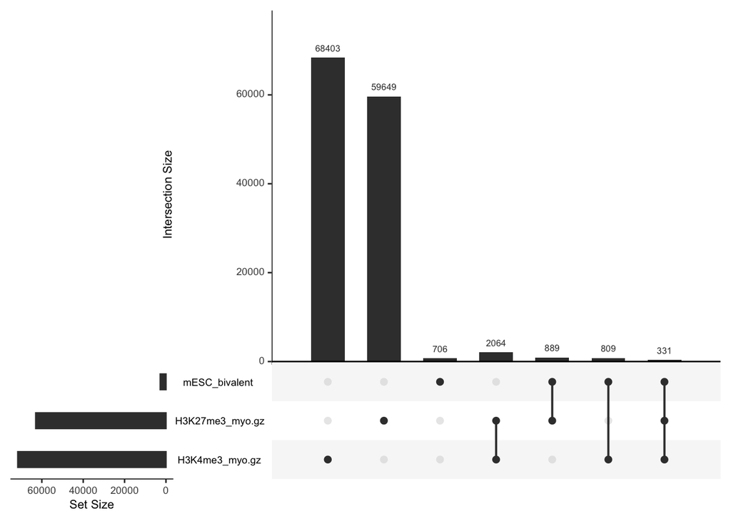

```r
regionUpset(peaks)
```

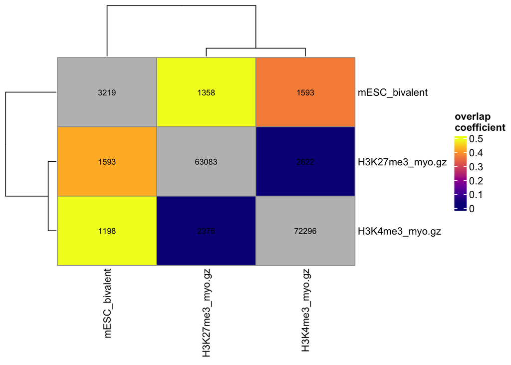

```r
regionOverlaps(peaks)
```